# Assignment 3

Madeline Berger

2026-01-29

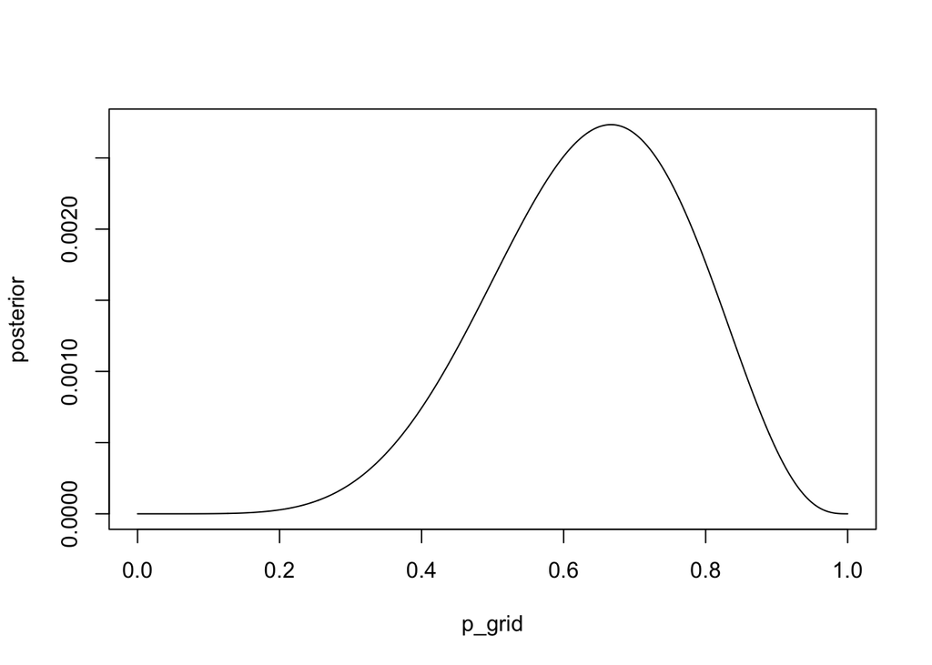

```r
p_grid <- seq(from = 0, to = 1, length.out = 1000) # a grid of probablities

prior <- rep(1,1000)
likelihood <- dbinom(6, size = 9, prob = p_grid)
posterior <- likelihood * prior
posterior <- likelihood / sum(posterior)


set.seed(100)

samples <- sample(p_grid, prob = posterior, size = 1e4, replace = TRUE) # draw samples from the posterior

#hist(posterior)

plot(posterior ~ p_grid, type = "l")
```

#### 3E1: How much posterior lies below *p* = 0.2?

```r
# first attempt:

#le_0.2 <- length(posterior[posterior < 0.2]) # all of it? not right

# second attempt
#sum(samples[samples < 0.2])

sum(samples < 0.2)
```

```
## [1] 4
```

```r
sum(samples < 0.2) / 1e4
```

```
## [1] 4e-04
```

**Answer:** Only 4 samples have a value of less than 0.2, meaning 4 x 10-4 of the posterior lies below 0.2

#### 3E4: 20% of the posterior probability lies below which value of *p*?

```r
# also: at what p is the 20% "line"
quantile(samples, 0.2)
```

```
##       20%
## 0.5185185
```

**Answer:** 20% of the posterior probability lies below *p* = 0.518

#### 3E6: Which of the values of *p* contain 66% of the posterior probability, assuming equal posterior probability both below and above the interval?

```r
# this is what the HPDI is for

HPDI(samples, prob = 0.66)
```

```
##     |0.66     0.66|
## 0.5085085 0.7737738
```

**Answer:** 66% of the posterior probability lies between (rounded) p = 0.51 and p = 0.77.

#### 3M1: Suppose the globe tossing data had turned out to be 8 water in 15 tosses. Construct the posterior distribution, using grid approximation. Use the same flat prior as before.

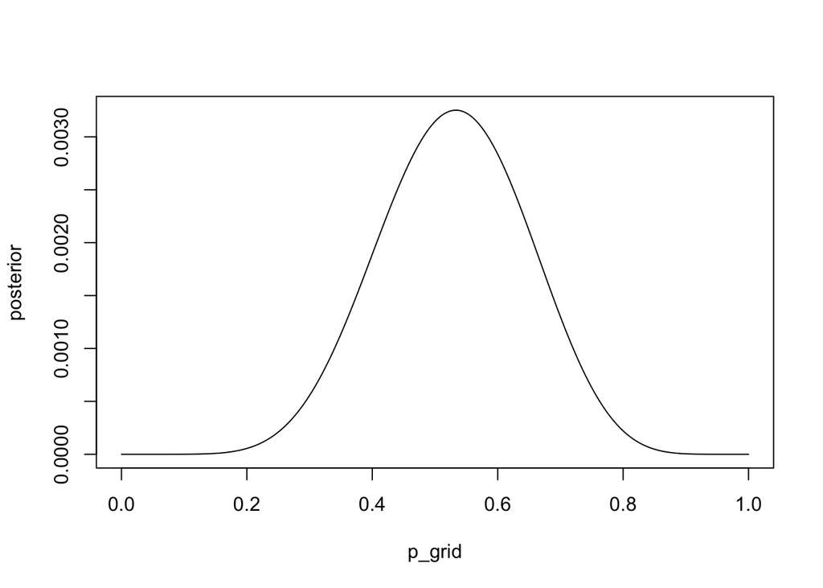

```r
# define the grid, uniform prior for p

p_grid <- seq(from = 0, to = 1, length.out = 1000)

# define prior - not sure I did this right
prior <- rep(1,1000)

#compute likelihood
likelihood <- dbinom(8, size = 15, prob = p_grid)

# compute product of likelihood and prior
unstd.posterior <- likelihood * prior

# standardize Posterior

posterior <- unstd.posterior / sum(unstd.posterior)

#hist(posterior)

#simplehist(posterior) # this is not working for me idk why

plot(posterior ~ p_grid, type = "l")
```

### 3M2. Draw 10,000 samples from the grid approximation from above. Then use the samples to calculate the 90% HPDI for p.

```r
samples <- sample(p_grid, prob = posterior, size = 10000, replace = T)
HPDI(samples, prob = 0.9)
```

```
##      |0.9      0.9|
## 0.3293293 0.7167167
```

#### 3M3. Construct a posterior predictive check for this model and data. This means simulate the distribution of samples, averaging over the posterior uncertainty in p. What is the probability of observing 8 water in 15 tosses?

Note: Asking for probability of 8 is essentially saying: how often do we see 8, in proportion to all samples?

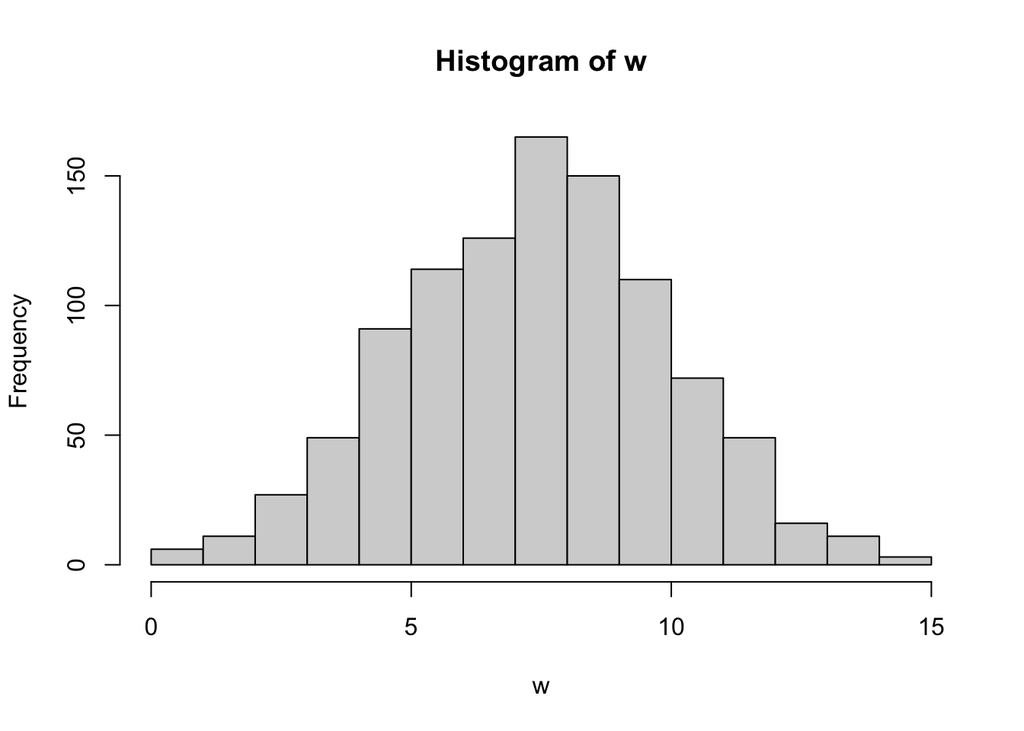

```r
set.seed(100) # so its the same answer everytime

w <- rbinom(1000, size = 15, prob =  samples)

hist(w)
```

```r
sum (w == 8) / length(w)
```

```
## [1] 0.165
```